# Data Science 2 - Assignment 1

David Utassy

2021 03 17

Needed packages and initializing h2o and the common seed:

```r
library(tidyverse)
library(ggplot2)
library(janitor)
library(kableExtra)
library(ggpubr)

library(h2o)
library(rpart)
library(rpart.plot)
library(data.tree)
h2o.init()
my_seed <- 20210317
```

# 1. Tree ensemble models (7 points)

In this problem you are going to work with the OJ dataset from the ISLR package. This dataset records purchases of two types of orange juices and presents customer and product characteristics as features. The goal is to predict which of the juices is chosen in a given purchase situation. See ?ISLR::OJ for a description of the variables.

First of all, I am importing the data and doing some exploratory data analysis. In order to reach a better prediction I did the following data cleaning and transformation:

- We can see that Store ID is a numeric variable, but it should be a factor as it should not contain any ordering or “distance” information.
- The StoreID contains the same information as Store, therefore I dropped Store.
- SpecialCH and SpecialMM variables are binary indicators, therefore I made them factor.
- WeekofPurchase is numeric and we might make it as a factor as well in order to achieve better results.

```r
data <- as_tibble(ISLR::OJ)
data <- clean_names(data)
skimr::skim(data)

data <- mutate(data,
  store_id = factor(store_id),
  special_ch = factor(special_ch),
  special_mm = factor(special_mm),
  weekof_purchase = factor(weekof_purchase),
  store = NULL
)
```

#### a. Create a training data of 75% and keep 25% of the data as a test set. Train a decision tree as a benchmark model. Plot the final model and interpret the result (using rpart and rpart.plot is an easier option).

I am creating h2o data from my data, then splitting the data to training and test set with the following code snippet. Also, I am defining here the outcome and the predictor variables.

```r
h2o_data <- as.h2o(data)

splitted_data <- h2o.splitFrame(h2o_data, ratios = 0.75, seed = my_seed)
data_train <- splitted_data[[1]]
data_test <- splitted_data[[2]]

y <- "purchase"
X <- setdiff(names(h2o_data), y)
```

```r
simple_tree <- h2o.randomForest(
  X, y,
  training_frame = data_train,
  model_id = "simple_tree",
  ntrees = 1, mtries = length(X), sample_rate = 1,
  max_depth = 5,
  nfolds = 4,
  seed = my_seed
)

source("h2o_tree_plotter.R")
simple_tree_plot <- plotH2OTree(h2o.getModelTree(model = simple_tree, tree_number = 1))
```

After training the model I plotted the tree produced by the model which is somewhat interpretable. From the splitting nodes we can clearly see that LoyalCH variable is very important as many of the nodes using it as a splitting variable. We can see that the more loyal the customer the more probability buying CH (Citrus Hill). PriceDiff shows the actual price of the two product (discounts included) and we can see that it is also an important variable. It is not a big surprise, but the cheaper CH compered to MM (Minute Maid) the more likely customers will purchase CH.

[interactive chart not shown]

#### b. Investigate tree ensemble models: random forest, gradient boosting machine, XGBoost. Try various tuning parameter combinations and select the best model using cross-validation.

##### Random Forest

In the following code snippet, I am tuning Random Forest model with a training grid to reach an optimal model. I am creating a plot concluding the performance of different tuning parameters with 5-fold cross-validation. (plot is in the appendix)

```r
rf_params <- list(
  ntrees = c(10, 50, 100, 300, 500),
  mtries = c(2, 4, 6, 8),
  sample_rate = c(0.2, 0.632, 1),
  max_depth = c(10, 20)
)

rf_grid <- h2o.grid(
  "randomForest", x = X, y = y,
  training_frame = data_train,
  grid_id = "rf",
  nfolds = 5,
  seed = my_seed,
  hyper_params = rf_params
)
```

```r
h2o.getGrid(rf_grid@grid_id, "auc")
best_rf <- h2o.getModel(
  h2o.getGrid(rf_grid@grid_id, sort_by = "auc", decreasing = TRUE)@model_ids[[1]]
)

rf_performance_summary <- h2o.getGrid(rf_grid@grid_id, "auc")@summary_table %>%
  as_tibble() %>%
  mutate(across(c("auc", names(rf_params)), as.numeric))

rf_summary_plot <- ggplot(rf_performance_summary, aes(ntrees, auc, color = factor(mtries))) +
  geom_line() +
  facet_grid(max_depth ~ sample_rate, labeller = label_both) +
  theme(legend.position = "bottom") +
  labs(color = "mtry")

#h2o.auc(h2o.performance(best_rf))
```

##### Gradient boosting machine

In the following code snippet, I am tuning GBM model with a training grid to reach an optimal model. I am creating a plot concluding the performance of different tuning parameters with 5-fold cross-validation. (plot is in the appendix)

```r
gbm_params <- list(
  learn_rate = c(0.01, 0.05, 0.1, 0.3),  # default: 0.1
  ntrees = c(10, 50, 100, 300, 500),
  max_depth = c(2, 5),
  sample_rate = c(0.2, 0.5, 0.8, 1)
)

gbm_grid <- h2o.grid(
  "gbm", x = X, y = y,
  grid_id = "gbm2",
  training_frame = data_train,
  nfolds = 5,
  seed = my_seed,
  hyper_params = gbm_params
)
```

```r
best_gbm <- h2o.getModel(
  h2o.getGrid(gbm_grid@grid_id, sort_by = "auc", decreasing = TRUE)@model_ids[[1]])

gbm_performance_summary <- h2o.getGrid(gbm_grid@grid_id, "auc")@summary_table %>%
  as_tibble() %>%
  mutate(across(c("auc", names(gbm_params)), as.numeric))
gbm_summary_plot <- ggplot(gbm_performance_summary, aes(ntrees, auc, color = factor(learn_rate))) +
  geom_line() +
  facet_grid(max_depth ~ sample_rate, labeller = label_both) +
  theme(legend.position = "bottom") +
  labs(color = "learning rate")

#h2o.auc(best_gbm, xval = TRUE)
```

##### XGBoost

In the following code snippet, I am tuning XGBoost model with a training grid to reach an optimal model. I am selecting the best model by using h2o’s built in 5-fold cross-validation.

```r
xgboost_params <- list(
  learn_rate = c(0.1, 0.3),  # same as "eta", default: 0.3
  ntrees = c(50, 100, 300),
  max_depth = c(2, 5),
  gamma = c(0, 1, 2),  # regularization parameter
  sample_rate = c(0.5, 1)
)

xgboost_grid <- h2o.grid(
  "xgboost", x = X, y = y,
  grid_id = "xgboost",
  training_frame = data_train,
  nfolds = 5,
  seed = my_seed,
  hyper_params = xgboost_params
)
best_xgboost <- h2o.getModel(
  h2o.getGrid(xgboost_grid@grid_id, sort_by = "auc", decreasing = TRUE)@model_ids[[1]]
)

#h2o.auc(h2o.performance(best_xgboost))
```

#### c. Compare the performance of the different models (if you use caret you should consider using the resamples function). Make sure to set the same seed before model training for all 3 models so that your cross validation samples are the same. Is any of these giving significantly different predictive power than the others?

I am using the AUC metric from the 5-fold cross-validation in order to compare the base-line and the tree ensemble models. We can see the results in the following table.

| Model | CV AUC |
| --- | --- |
| simple_tree | 0.8447 |
| gbm2_model_145 | 0.8920 |
| rf_model_35 | 0.8968 |
| xgboost_model_42 | 0.9082 |

[figure not shown]

#### e. Inspect variable importance plots for the 3 models. Are similar variables found to be the most important for the 3 models?

Up next we can see the variable importance plots of the models. We can see that they are very similar as the LoyalCH variable is outstandingly important everywhere. In the following places, there are some changes, but we can say that both models are very similar. One difference I want to highlight is that in the XGBOOST variable importance plot factor variables are not aggregated, which makes the difference compared to other plots.

###### Random forest

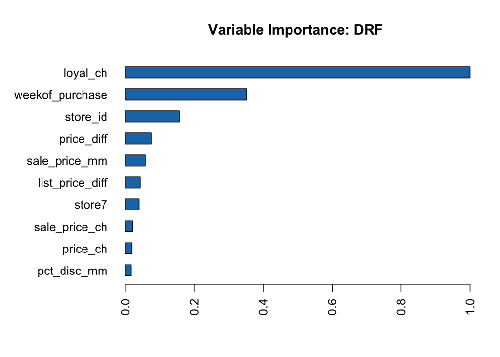

###### XGBOOST

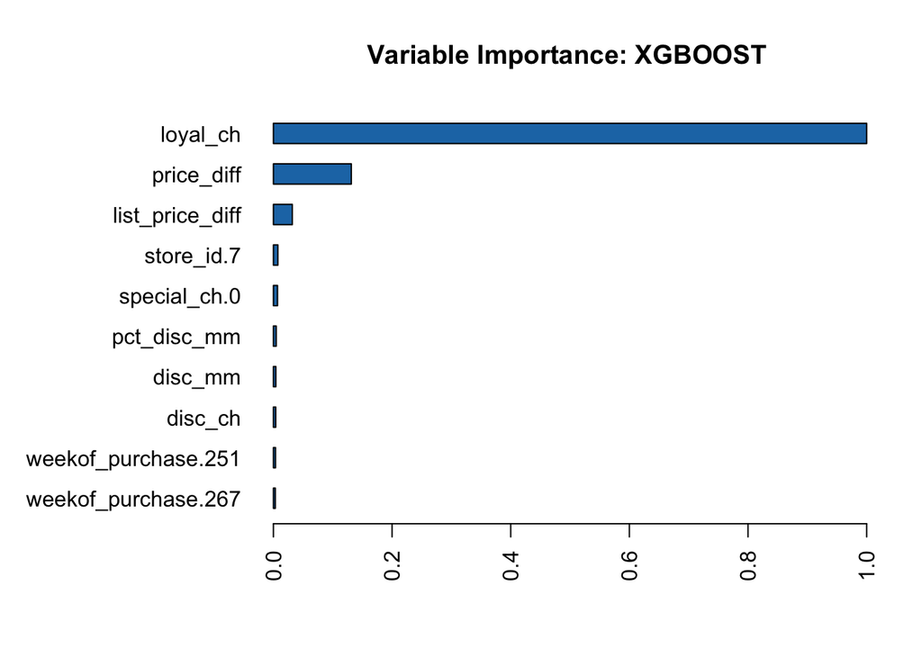

###### GBM

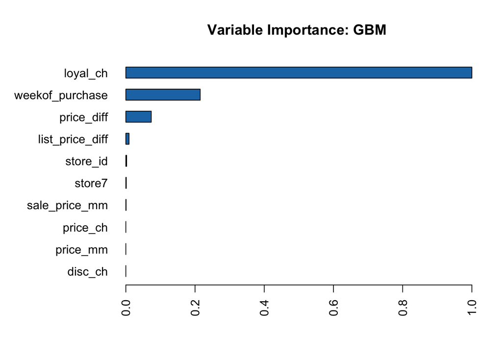

# 2. Variable importance profiles (6 points)

Use the Hitters dataset and predict log_salary just like we did it in class.

#### a. Train two random forest models: one with sampling 2 variables randomly for each split and one with 10 (use the whole dataset and don’t do cross-validation). Inspect variable importance profiles. What do you see in terms of how important the first few variables are relative to each other?

In the following code snippet I am training the two random forest models as described in the task above.

```r
y <- "log_salary"
X <- setdiff(names(h2o_data), y)

rf_2 <- h2o.randomForest(
  X, y,
  training_frame = data_train,
  model_id = "rfm_2",
  seed = my_seed,
  mtries = 2,
  sample_rate = 1
)

rf_10 <- h2o.randomForest(
  X, y,
  training_frame = data_train,
  model_id = "rfm_10",
  seed = my_seed,
  mtries = 10,
  sample_rate = 1
)
```

###### mtries=2

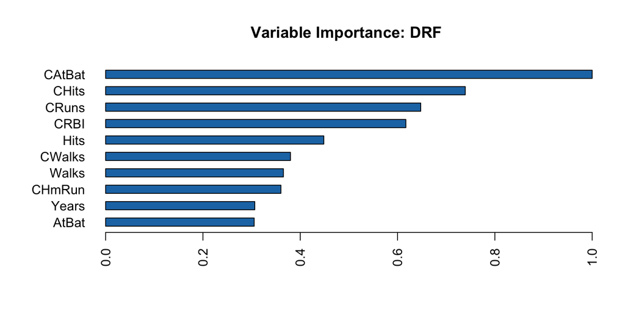

###### mtries=10

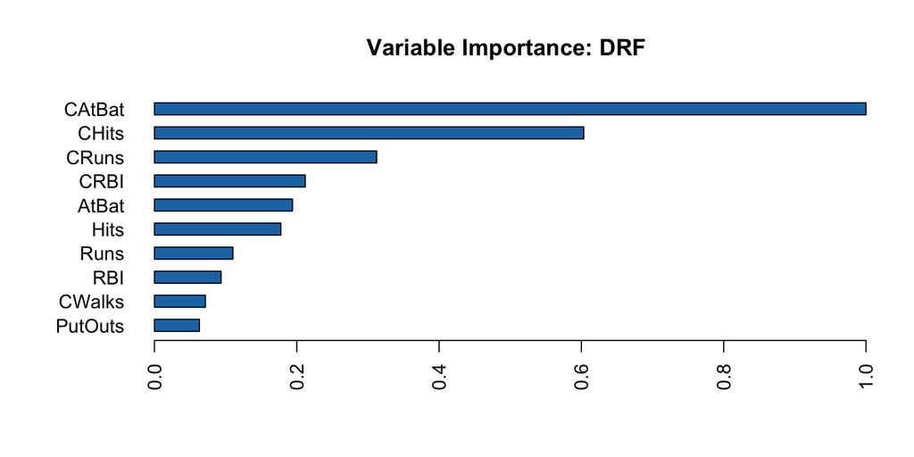

By showing the variable importance plots we can see, that the model with a lower number of sampling variables has a more balanced distribution between the most important variables, whereas the one with 10 sampling variables has a huge difference between variables regarding their importance.

#### b. One of them is more extreme in terms of how the most important and the next ones relate to each other. Give an intuitive explanation how mtry/mtries relates to relative importance of variables in random forest models.

My intuition is that if mtries is lower (meaning the model has fewer options to chose while splitting), then less important variables have more chance to become more important. In that sense, each tree is being less perfect. If we are allowing the training algorithm to choose the splitting variable from wide a wide scale, then important variables at that point will always overtake less important ones.

#### c. In the same vein, estimate two gbm models with varying rate of sampling for each tree (use 0.1 and 1 for the parameter bag.fraction/sample_rate). Hold all the other parameters fixed: grow 500 trees with maximum depths of 5, applying a learning rate of 0.1. Compare variable importance plots for the two models. Could you explain why is one variable importance profile more extreme than the other?

In the following code snippet I am training the two GBM models as described in the task above.

```r
gbm_01 <- h2o.gbm(
  x = X, y = y,
  model_id = "gbm_01",
  training_frame = data_train,
  seed = my_seed,
  sample_rate = 0.1,
  ntrees = 500,
  learn_rate = 0.1,
  max_depth = 5,
  nfolds = 0
)

gbm_1 <- h2o.gbm(
  x = X, y = y,
  model_id = "gbm_1",
  training_frame = data_train,
  seed = my_seed,
  sample_rate = 1,
  ntrees = 500,
  learn_rate = 0.1,
  max_depth = 5,
  nfolds = 0
)
```

###### sample_rate = 0.1

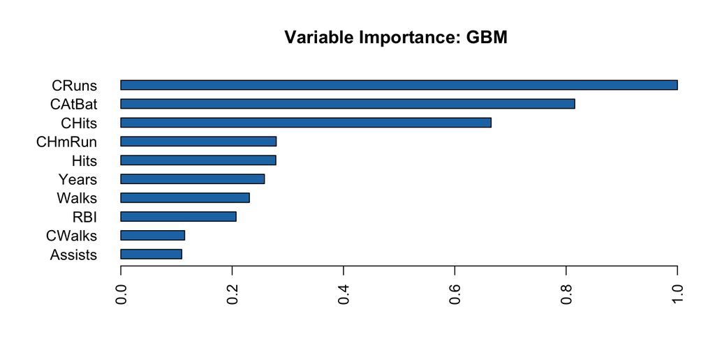

###### sample_rate = 1

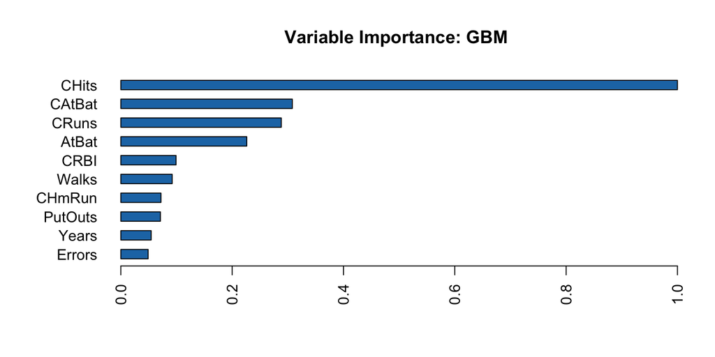

We can see that the variable importance plot of the one with 0.1 sample rate is more balanced between the most important variables. I think the reason for that is that h2o using random sub-samples (without replacement) and when sample_rate = 0.1 it means that it using only random 10% of the data. This randomization gives an opportunity to less powerful variables to become relatively more important in the model resulting in a more balanced distribution on the variable importance plot.

# 3. Stacking (10 points)

In this problem you are going to predict whether patients actually show up for their medical appointments. The dataset was shared on Kaggle.

At first, I did the following basic steps:

- Reading the data
- Cleaning the data
- Feature engineering

#### a. Create train / validation / test sets, cutting the data into 5% - 45% - 50% parts.

```r
h2o_data <- as.h2o(data)

splitted_data <- h2o.splitFrame(h2o_data, ratios = c(0.05, 0.5), seed = my_seed)
data_train <- splitted_data[[1]]
data_valid <- splitted_data[[2]]
data_test <- splitted_data[[3]]

y <- "no_show"
X <- setdiff(names(h2o_data), y)
```

#### b. Train a benchmark model of your choice (such as random forest, gbm or glm) and evaluate it on the validation set.

I decided to use a GBM model as a benchmark model, which has a cross-validated AUC of 0.5682 on the validation set.

```r
simple_gbm <- h2o.gbm(
  x = X, y = y,
  model_id = "simple_gbm",
  training_frame = data_train,
  nfolds = 5,
  seed = my_seed
)
h2o.auc(h2o.performance(simple_gbm, data_valid))
```

#### c. Build at least 3 models of different families using cross validation, keeping cross validated predictions. You might also try deeplearning.

I made the decision to train the following models:

- Lasso
- Random Forest
- Deep Learning
- Gradient Boosting Machine

The training of these models are the following:

```r
glm_model3 <- h2o.glm(
  X, y,
  training_frame = data_train,
  model_id = "lasso3",
  family = "binomial",
  alpha = 1,
  lambda_search = TRUE,
  seed = my_seed,
  nfolds = 5,
  keep_cross_validation_predictions = TRUE  # this is necessary to perform later stacking
)
```

```r
rf_model3 <- h2o.randomForest(
  X, y,
  training_frame = data_train,
  model_id = "rf3",
  ntrees = 200,
  max_depth = 10,
  seed = my_seed,
  nfolds = 5,
  keep_cross_validation_predictions = TRUE
)
```

```r
deeplearning_model3 <- h2o.deeplearning(
  X, y,
  training_frame = data_train,
  model_id = "deeplearning3",
  hidden = c(32, 8),
  seed = my_seed,
  nfolds = 5,
  keep_cross_validation_predictions = TRUE
)
```

```r
gbm_model3 <- h2o.gbm(
  X, y,
  training_frame = data_train,
  model_id = "gbm3",
  ntrees = 200,
  max_depth = 5,
  learn_rate = 0.1,
  seed = my_seed,
  nfolds = 5,
  keep_cross_validation_predictions = TRUE
)
```

#### d. Evaluate validation set performance of each model.

In the table below we can see the cross-validated AUC on the validation set for all of the models. (Note that the cross-validated AUC of for the baseline GBM model was 0.5682 on the validation set.).

|  | AUC (validation) |
| --- | --- |
| Lasso | 0.5703 |
| RF | 0.5733 |
| DL | 0.5697 |
| GBM | 0.5529 |

#### e. How large are the correlations of predicted scores of the validation set produced by the base learners?

To visualize the correlation between the models we can plot heatmap showing the correlation matrix. It is interesting to see, that there is a great correlation between lasso, random forest and deep learning, however the GBM models seems to be different. (It had a poorer AUC performance as well)

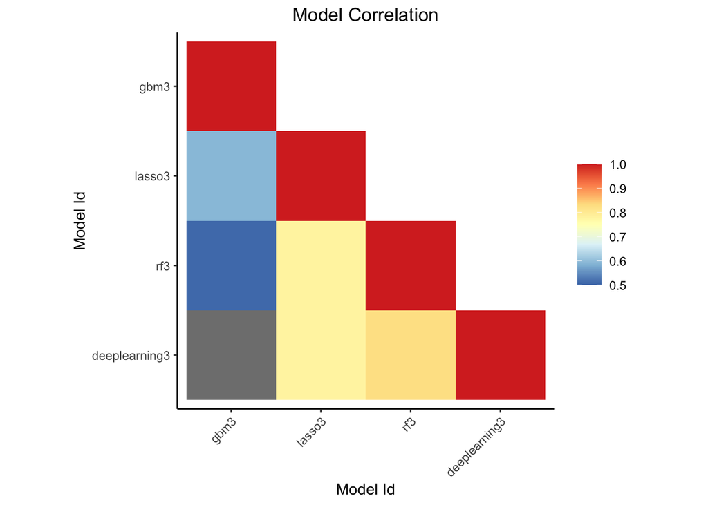

#### f. Create a stacked ensemble model from the base learners.

Let’s combine these models by training a meta learner model on top of them. First I am training with a default GLM meta learner, then I am using a GBM meta lerner in the following code snippet.

```r
ensemble_model <- h2o.stackedEnsemble(
  X, y,
  training_frame = data_train,
  base_models = my_models,
  keep_levelone_frame = TRUE
)

ensemble_model_gbm <- h2o.stackedEnsemble(
  X, y,
  training_frame = data_train,
  metalearner_algorithm = "gbm",
  base_models = my_models
)
```

#### g. Evaluate ensembles on validation set. Did it improve prediction?

```r
h2o.auc(h2o.performance(ensemble_model, data_valid))
h2o.auc(h2o.performance(ensemble_model_gbm, data_valid))
```

[output not shown]

#### h. Evaluate the best performing model on the test set. How does performance compare to that of the validation set?

```r
h2o.auc(h2o.performance(ensemble_model, newdata = data_test))
```

# Appendix

## 1 exercise

#### Summary plot for Random forest tuning

From the following plot we can see that the best RF models turned out to be the ones with small sample rate, with maximum depth 10. We can see that after 300 trees almost all the options reached the optimal state.

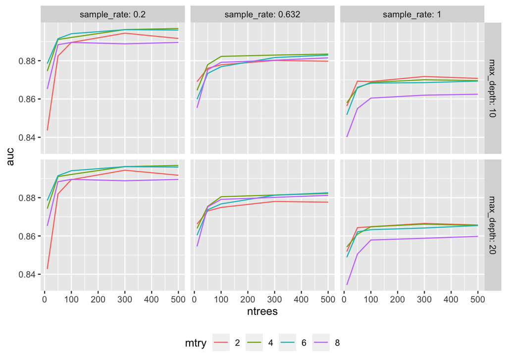

#### Summary plot for GBM tuning

From the following plot we can see that with GBM models overfitting is really frequent, especially whey using high learning rate, and deep trees. Also we can see that with small learning rate, it is just the matter of time (number of trees) when we reach great performing models.

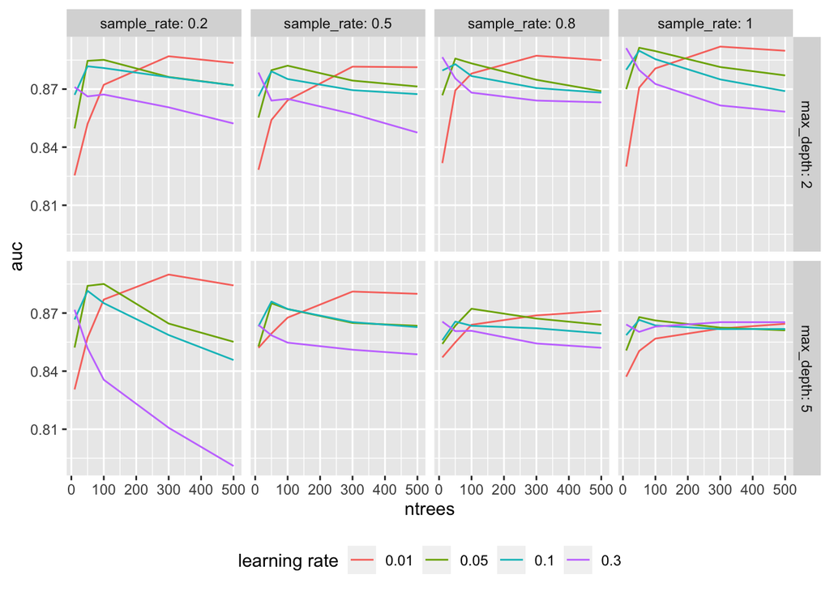